# Python Data Science

> Array Computing with NumPy

Kuo, Yao-Jen from [DATAINPOINT](https://www.datainpoint.com/)

```python
# Importing libraries
import numpy as np
import matplotlib.pyplot as plt
import time
```

# TL; DR

> In this lecture, we will introduce the fundamentals of array computing in Python with `numpy`.

## Getting Started with NumPy

## What is NumPy?

> NumPy, as in numerical Python is the fundamental package for scientific computing in Python. It is a Python library that provides a multidimensional array object and an assortment of routines for fast operations on arrays, including mathematical, logical, shape manipulation, sorting, selecting, I/O, discrete Fourier transforms, basic linear algebra, basic statistical operations, random simulation and much more.

Source: https://numpy.org/

## Import NumPy with `import` command

NumPy is officially aliased as `np`.

```python
import numpy as np
```

## If NumPy is not installed, we will encounter a `ModuleNotFoundError`

```
Traceback (most recent call last):
  File "<stdin>", line 1, in <module>
ModuleNotFoundError: No module named 'numpy'
```

## Use `pip install` at Terminal to install numpy

```
pip install numpy
```

## Check version and its installation file path

- `__version__` attribute
- `__file__` attribute

```python
print(np.__version__)
print(np.__file__)
```

```
1.19.1
/opt/conda/lib/python3.8/site-packages/numpy/__init__.py
```

## Why NumPy?

> Python's built-in data structures come with great flexibility that is able to contain heterogeneous data types, however, this flexibility comes at a cost: to allow these flexible types, each item in the list must contain its own type info, reference count, and other information–that is, each item is a complete Python object. Fixed-type arrays lack this flexibility, but are much more efficient for storing and manipulating data.

## A heterogenous `list`

```python
heterogeneous_list = [5566, 55.66, True, False, '5566']
print(type(heterogeneous_list))
for i in heterogeneous_list:
    print(type(i))
```

```
<class 'list'>
<class 'int'>
<class 'float'>
<class 'bool'>
<class 'bool'>
<class 'str'>
```

## A homogeneous `ndarray`

```python
homogeneous_arr = np.array(heterogeneous_list)
print(type(homogeneous_arr))
for i in homogeneous_arr:
    print(type(i))
```

```
<class 'numpy.ndarray'>
<class 'numpy.str_'>
<class 'numpy.str_'>
<class 'numpy.str_'>
<class 'numpy.str_'>
<class 'numpy.str_'>
```

## The advantage of fix typed arrays

More efficient for storing and manipulating data.

```python
m = 10000000
large_array = np.random.randint(1, 100, size=m)
large_list = list(large_array)
print(type(large_list))
print(type(large_array))
```

```
<class 'list'>
<class 'numpy.ndarray'>
```

```python
# Computing reciprocals for large list
start_time = time.time()
reciprocals = [1 / i for i in large_list]
end_time = time.time()
computing_time = end_time - start_time
print("Computing time for {:,} repicprocals: {:.2f} seconds.".format(m, computing_time))
```

```
Computing time for 10,000,000 repicprocals: 2.83 seconds.
```

```python
# Computing for large array
start_time = time.time()
reciprocals = 1 / large_array
end_time = time.time()
computing_time = end_time - start_time
print("Computing time for {:,} repicprocals: {:.2f} seconds.".format(m, computing_time))
```

```
Computing time for 10,000,000 repicprocals: 0.93 seconds.
```

## Key functionalities we rely on NumPy are:

- Array manipulations
- Universal/Aggregate functions

## Creating arrays

## What is a `ndarray`?

> A ndarray is a grid of values, all of the same type, and is indexed by a tuple of nonnegative integers. The number of dimensions is the rank of the array; the shape of an array is a tuple of integers giving the size of the array along each dimension.

## Creating arrays from lists

```python
lst = list(range(1, 12))
print(type(lst))
arr = np.array(lst)
print(type(arr))
```

```
<class 'list'>
<class 'numpy.ndarray'>
```

## Creating arrays from scratch: zeros, ones, and full functions

```python
print(np.zeros(5))
print(np.ones(5))
print(np.full(5, 6.0))
```

```
[0. 0. 0. 0. 0.]
[1. 1. 1. 1. 1.]
[6. 6. 6. 6. 6.]
```

## Creating arrays from scratch: generating sequences

```python
print(np.arange(1, 11, 2))
print(np.linspace(1, 9, 5))
```

```
[1 3 5 7 9]
[1. 3. 5. 7. 9.]
```

## Creating arrays from scratch: randomness

```python
uniform_arr = np.random.random(10000)
normal_arr = np.random.normal(0, 1, 10000)
randint_arr = np.random.randint(1, 7, size=10000)
print(uniform_arr)
print(normal_arr)
print(randint_arr)
```

```
[0.73792464 0.74642179 0.55549602 ... 0.81067906 0.78549208 0.99688446]
[-0.75076859  1.349652   -0.66170795 ...  0.26998782  0.03278454
 -0.39891154]
[1 4 3 ... 3 3 4]
```

## Validating distribution with histograms

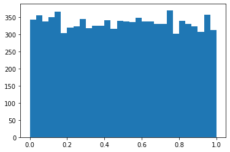

```python
fig = plt.figure()
ax = plt.axes()
ax.hist(uniform_arr, bins=30)
plt.show()
```

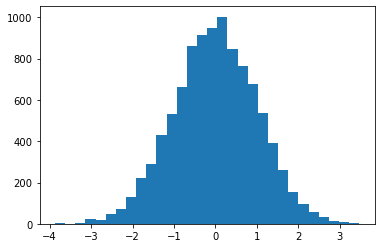

```python
fig = plt.figure()
ax = plt.axes()
ax.hist(normal_arr, bins=30)
plt.show()
```

## Common attributes to examin for a `ndarray`

- `ndim`: as in number of dimensions
- `shape`
- `size`
- `dtype`: as in data type

```python
arr = np.array([5, 5, 6, 6])
print(arr.ndim)
print(arr.shape)
print(arr.size)
print(arr.dtype)
```

```
1
(4,)
4
int64
```

## Different nicknames vs. different number of dimensions

- Scalar: 0-dimension
- Vector: 1-dimension
- Matrix: 2-dimension
- Tensorf: 3-dimension or more